IE 360 HW2 ATIF YÖNET 2018402174

INTRODUCTION My aim in this homework is forecasting the sales of UGS for every quarter of 2007 by using the data from years between 2000 and 2006 and a number of potential independent variables.

I install the required packages and libraries and prepare the data for the analysis and divide it.

```r
install.packages("corrplot")
install.packages("ggcorrplot")
install.packages("GGally")
install.packages("forecast")
install.packages("dplyr")
install.packages("RcppRoll")
install.packages("readxl")
install.packages("lubridate")
install.packages("zoo")
install.packages("ggplot2")
install.packages("scales")
install.packages("data.table")
library(corrplot)
library(ggcorrplot)
library(GGally)
library(forecast)
library(dplyr)
library(RcppRoll)
library(readxl)
library(lubridate)
library(zoo)
library(ggplot2)
library(scales)
library(data.table)
```

[output not shown]

```
installing the source package 'corrplot'
```

[output not shown]

[output not shown]

[output not shown]

[output not shown]

```
readxl  1.3.1  1.4.0              TRUE

  Binaries will be installed
```

```
lubridate 1.7.10  1.8.0              TRUE

  Binaries will be installed
```

```
zoo  1.8-9 1.8-10              TRUE

  Binaries will be installed
```

```
ggplot2  3.3.3  3.3.6             FALSE
```

```
installing the source package 'ggplot2'
```

[output not shown]

[output not shown]

[output not shown]

```r
data <- read.csv("IE360_Spring22_HW2_data.csv",colClasses=c('character',rep('numeric',10)))
summary(data)
data
data$Quarter=as.Date(as.yearqtr(data$Quarter,format="%Y_Q%q"))
datatr=data.table(data[c(1:28),])
datafore=data.table(data[c(29,30,31,32),])
str(datatr)
str(datafore)
```

```
   Quarter          Unleaded.Gasoline.Sale..UGS.      RNUV
 Length:32          Min.   : 736580              Min.   :0.001200
 Class :character   1st Qu.: 876211              1st Qu.:0.004100
 Mode  :character   Median : 983573              Median :0.007250
                    Mean   : 987212              Mean   :0.008906
                    3rd Qu.:1097324              3rd Qu.:0.013150
                    Max.   :1370167              Max.   :0.020700
                    NA's   :4
 X..LPG.Vehicles..NLPG. Price.of.Unleaded.Gasoline..PU.
 Min.   : 940000        Min.   :402.1
 1st Qu.: 997500        1st Qu.:479.2
 Median :1352000        Median :526.7
 Mean   :1299922        Mean   :519.2
 3rd Qu.:1602000        3rd Qu.:565.2
 Max.   :1797400        Max.   :609.0

 Price.of.Diesel.Gasoline..PG. X..Unleaded.Gasoline.Vehicles..NUGV.
 Min.   :300.7                 Min.   :4647500
 1st Qu.:366.9                 1st Qu.:5029281
 Median :401.6                 Median :5186068
 Mean   :400.4                 Mean   :5296758
 3rd Qu.:449.2                 3rd Qu.:5604709
 Max.   :471.9                 Max.   :6065597

 X..of.Diesel.Gasoline.Vehicles..NDGV. GNP.Agriculture    GNP.Commerce
 Min.   :282.0                         Min.   : 832953   Min.   :3374849
 1st Qu.:286.6                         1st Qu.:1348066   1st Qu.:4403081
 Median :291.9                         Median :1850657   Median :5124300
 Mean   :304.9                         Mean   :2895561   Mean   :5246534
 3rd Qu.:322.9                         3rd Qu.:3922950   3rd Qu.:5967433
 Max.   :357.3                         Max.   :7140722   Max.   :7480414

   GNP.Total
 Min.   :15832648
 1st Qu.:21790148
 Median :25229712
 Mean   :25745763
 3rd Qu.:29843404
 Max.   :36741745
```

| Quarter | Unleaded.Gasoline.Sale..UGS. | RNUV | X..LPG.Vehicles..NLPG. | Price.of.Unleaded.Gasoline..PU. | Price.of.Diesel.Gasoline..PG. | X..Unleaded.Gasoline.Vehicles..NUGV. | X..of.Diesel.Gasoline.Vehicles..NDGV. | GNP.Agriculture | GNP.Commerce | GNP.Total |
| --- | --- | --- | --- | --- | --- | --- | --- | --- | --- | --- |
| 2000_Q1 | 1128971 | 0.0146 | 940000 | 469.03 | 355.69 | 4647500 | 281.9853 | 1040173 | 3483132 | 18022686 |
| 2000_Q2 | 1199569 | 0.0205 | 941000 | 459.42 | 344.58 | 4742876 | 284.0813 | 1760460 | 4525451 | 21797130 |
| 2000_Q3 | 1370167 | 0.0207 | 943500 | 439.98 | 327.21 | 4840931 | 286.7169 | 6974808 | 5915204 | 30050207 |
| 2000_Q4 | 1127548 | 0.0163 | 948000 | 402.08 | 300.67 | 4919685 | 288.3137 | 3267125 | 4929778 | 24480153 |
| 2001_Q1 | 1033918 | 0.0071 | 950000 | 411.58 | 305.75 | 4954754 | 287.6237 | 1004528 | 3418387 | 15832648 |
| 2001_Q2 | 1019754 | 0.0051 | 955000 | 520.39 | 374.78 | 4980204 | 287.8814 | 1449357 | 4359831 | 20296918 |
| 2001_Q3 | 1209916 | 0.0041 | 967500 | 530.37 | 398.71 | 5000446 | 287.5452 | 5890424 | 5925547 | 28017963 |
| 2001_Q4 | 1002789 | 0.0048 | 990000 | 496.35 | 370.70 | 5024693 | 286.9786 | 1940854 | 4559190 | 22656812 |
| 2002_Q1 | 893722 | 0.0012 | 1000000 | 479.52 | 352.72 | 5030810 | 286.3783 | 832953 | 3374849 | 18393446 |
| 2002_Q2 | 1027252 | 0.0032 | 1001000 | 506.36 | 373.44 | 5046960 | 286.0471 | 1419764 | 4363782 | 20382635 |
| 2002_Q3 | 1153265 | 0.0034 | 1003500 | 533.66 | 404.49 | 5064066 | 285.8790 | 6340745 | 6229580 | 29835296 |
| 2002_Q4 | 991981 | 0.0044 | 1008000 | 506.90 | 390.75 | 5086547 | 286.1087 | 2258470 | 5057739 | 25813612 |
| 2003_Q1 | 806257 | 0.0019 | 1010000 | 537.50 | 425.00 | 5096278 | 285.8286 | 841604 | 3933013 | 20084070 |
| 2003_Q2 | 960556 | 0.0056 | 1048000 | 502.06 | 382.47 | 5125065 | 286.2459 | 1519490 | 4395167 | 21769200 |
| 2003_Q3 | 1104825 | 0.0041 | 1143000 | 488.72 | 374.48 | 5146129 | 287.7798 | 6952669 | 6096102 | 30878474 |
| 2003_Q4 | 934022 | 0.0062 | 1314000 | 455.83 | 351.18 | 5178274 | 290.2288 | 2112006 | 5035207 | 25427354 |
| 2004_Q1 | 832350 | 0.0030 | 1390000 | 454.11 | 352.22 | 5193861 | 293.5030 | 1025366 | 4055284 | 20692122 |
| 2004_Q2 | 975165 | 0.0030 | 1401000 | 478.20 | 372.54 | 5209448 | 296.7488 | 1621092 | 5190860 | 24061451 |
| 2004_Q3 | 1094823 | 0.0051 | 1428500 | 522.95 | 408.34 | 5236227 | 298.6176 | 6932300 | 6886243 | 33270727 |
| 2004_Q4 | 854517 | 0.0181 | 1478000 | 561.67 | 438.75 | 5330892 | 303.1641 | 2408982 | 5847940 | 28644792 |
| 2005_Q1 | 762559 | 0.0035 | 1500000 | 571.48 | 438.67 | 5349584 | 305.5032 | 1027640 | 4405719 | 22144043 |
| 2005_Q2 | 890693 | 0.0131 | 1512000 | 591.14 | 456.19 | 5419927 | 310.4279 | 1424674 | 5308303 | 25032070 |
| 2005_Q3 | 1040946 | 0.0162 | 1542000 | 609.03 | 471.86 | 5507485 | 316.2897 | 6476845 | 6784956 | 33325846 |
| 2005_Q4 | 793399 | 0.0158 | 1596000 | 565.19 | 449.19 | 5594288 | 322.2079 | 2193688 | 5802943 | 28445453 |
| 2006_Q1 | 736580 | 0.0080 | 1620000 | 565.19 | 449.19 | 5635972 | 324.9761 | 1079022 | 4626005 | 23251245 |
| 2006_Q2 | 877614 | 0.0114 | 1629500 | 565.19 | 449.19 | 5696182 | 329.4702 | 1495908 | 5573718 | 26283673 |
| 2006_Q3 | 946783 | 0.0108 | 1653250 | 565.19 | 449.19 | 5754077 | 333.7144 | 6800688 | 7124204 | 34992138 |
| 2006_Q4 | 872000 | 0.0133 | 1696000 | 565.19 | 449.19 | 5825866 | 339.2281 | 2303373 | 6093090 | 29867726 |
| 2007_Q1 | NA | 0.0074 | 1715000 | 565.19 | 449.19 | 5869018 | 342.1729 | 1132973 | 4857305 | 24413807 |
| 2007_Q2 | NA | 0.0106 | 1725300 | 565.19 | 449.19 | 5931348 | 346.9407 | 1570703 | 5852404 | 27597857 |
| 2007_Q3 | NA | 0.0101 | 1751050 | 565.19 | 449.19 | 5991280 | 351.4449 | 7140722 | 7480414 | 36741745 |
| 2007_Q4 | NA | 0.0124 | 1797400 | 565.19 | 449.19 | 6065597 | 357.2902 | 2418541 | 6397745 | 31361112 |

```
Classes 'data.table' and 'data.frame':	28 obs. of  11 variables:
 $ Quarter                              : Date, format: "2000-01-01" "2000-04-01" ...
 $ Unleaded.Gasoline.Sale..UGS.         : num  1128971 1199569 1370167 1127548 1033918 ...
 $ RNUV                                 : num  0.0146 0.0205 0.0207 0.0163 0.0071 0.0051 0.0041 0.0048 0.0012 0.0032 ...
 $ X..LPG.Vehicles..NLPG.               : num  940000 941000 943500 948000 950000 ...
 $ Price.of.Unleaded.Gasoline..PU.      : num  469 459 440 402 412 ...
 $ Price.of.Diesel.Gasoline..PG.        : num  356 345 327 301 306 ...
 $ X..Unleaded.Gasoline.Vehicles..NUGV. : num  4647500 4742876 4840931 4919685 4954754 ...
 $ X..of.Diesel.Gasoline.Vehicles..NDGV.: num  282 284 287 288 288 ...
 $ GNP.Agriculture                      : num  1040173 1760460 6974808 3267125 1004528 ...
 $ GNP.Commerce                         : num  3483132 4525451 5915204 4929778 3418387 ...
 $ GNP.Total                            : num  18022686 21797130 30050207 24480153 15832648 ...
 - attr(*, ".internal.selfref")=<externalptr>
Classes 'data.table' and 'data.frame':	4 obs. of  11 variables:
 $ Quarter                              : Date, format: "2007-01-01" "2007-04-01" ...
 $ Unleaded.Gasoline.Sale..UGS.         : num  NA NA NA NA
 $ RNUV                                 : num  0.0074 0.0106 0.0101 0.0124
 $ X..LPG.Vehicles..NLPG.               : num  1715000 1725300 1751050 1797400
 $ Price.of.Unleaded.Gasoline..PU.      : num  565 565 565 565
 $ Price.of.Diesel.Gasoline..PG.        : num  449 449 449 449
 $ X..Unleaded.Gasoline.Vehicles..NUGV. : num  5869018 5931348 5991280 6065597
 $ X..of.Diesel.Gasoline.Vehicles..NDGV.: num  342 347 351 357
 $ GNP.Agriculture                      : num  1132973 1570703 7140722 2418541
 $ GNP.Commerce                         : num  4857305 5852404 7480414 6397745
 $ GNP.Total                            : num  24413807 27597857 36741745 31361112
 - attr(*, ".internal.selfref")=<externalptr>
```

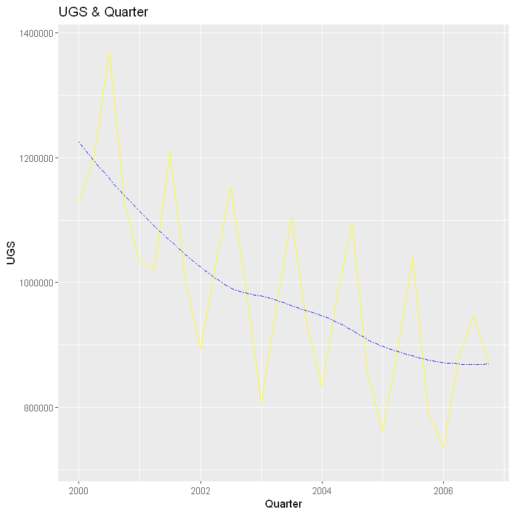

```r
ggp1 <- ggplot(data = datatr,aes(x = Quarter,y = Unleaded.Gasoline.Sale..UGS.))
ggp1 + geom_line(color ="yellow") +
  geom_smooth(fill = NA, color="blue",linetype = "twodash", size = 0.5) +
  labs(title = "UGS & Quarter",
       x = "Quarter",
       y = "UGS" )
```

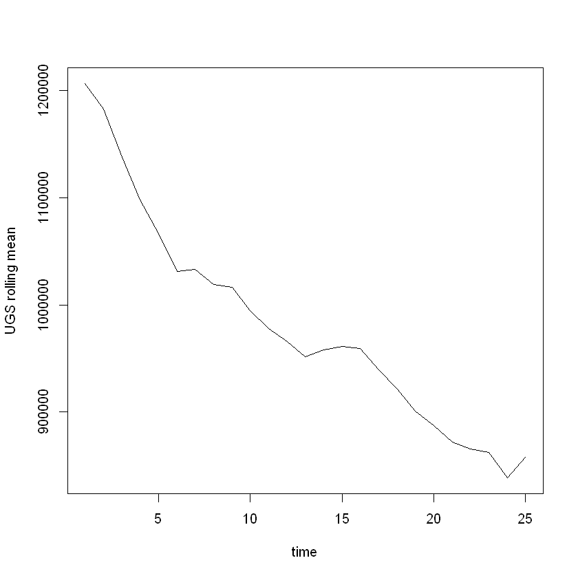

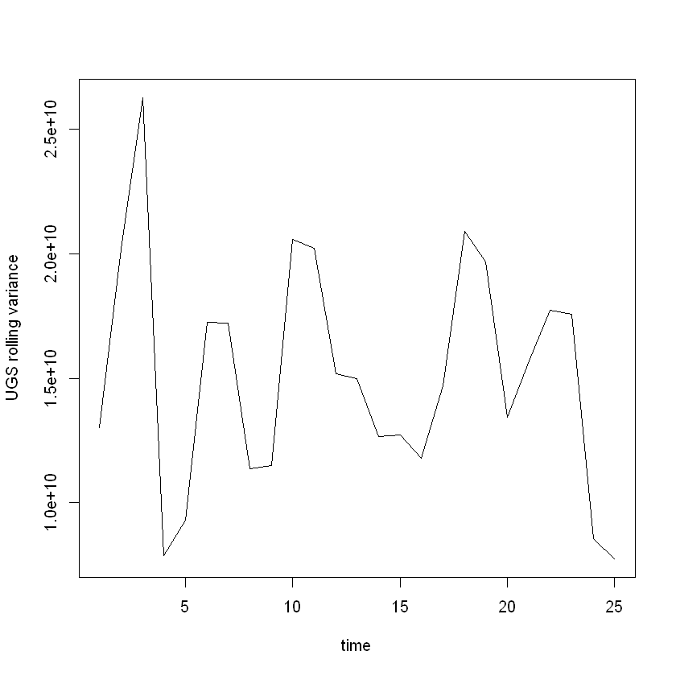

```r
mseries=roll_mean(datatr$Unleaded.Gasoline.Sale..UGS.,4,align='left')
plot(mseries,
     type='l',col='black',
     xlab = "time",
     ylab = "UGS rolling mean")
varseries=roll_var(datatr$Unleaded.Gasoline.Sale..UGS.,4,align='left')
plot(varseries,
     type='l',col='black',
     xlab = "time",
     ylab = "UGS rolling variance"
)
```

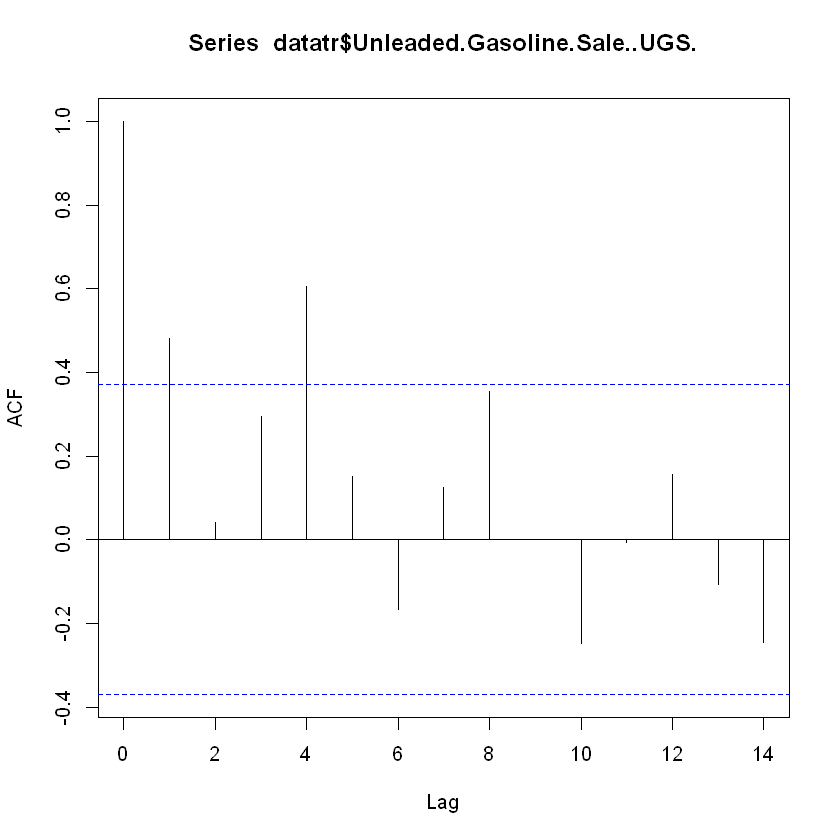

```r
acf(datatr$Unleaded.Gasoline.Sale..UGS.)
```

Data is strongly correlated. Because lag 4 has a high value it shows the seasonality effects and lag 1 has a high value too, it shows the trend effect.

In model 1 because data has strong trend and seasonality effect I added them into my model and check if I can create a good model by just adding them. And I do not add any regressors.

```r
datatr[,trend := 1:.N ]
datatr[,Quarter_:=as.character(month(Quarter))]
datafore[,trend := 29:32 ]
datafore[,Quarter_:=as.character(month(Quarter))]
model1 <- lm(Unleaded.Gasoline.Sale..UGS. ~ trend+Quarter_, datatr)
model1
summary(model1)
```

```
Call:
lm(formula = Unleaded.Gasoline.Sale..UGS. ~ trend + Quarter_,
    data = datatr)

Coefficients:
(Intercept)        trend   Quarter_10    Quarter_4    Quarter_7
    1060372       -13497        95049       121532       273618
```

```
Call:
lm(formula = Unleaded.Gasoline.Sale..UGS. ~ trend + Quarter_,
    data = datatr)

Residuals:
   Min     1Q Median     3Q    Max
-81167 -31283  -3458  28640  94502

Coefficients:
            Estimate Std. Error t value Pr(>|t|)
(Intercept)  1060372      23653  44.830  < 2e-16 ***
trend         -13497       1147 -11.764 3.28e-11 ***
Quarter_10     95049      26189   3.629 0.001405 **
Quarter_4     121532      25987   4.677 0.000104 ***
Quarter_7     273619      26063  10.498 3.03e-10 ***
---
Signif. codes:  0 '***' 0.001 '**' 0.01 '*' 0.05 '.' 0.1 ' ' 1

Residual standard error: 48570 on 23 degrees of freedom
Multiple R-squared:  0.9119,	Adjusted R-squared:  0.8966
F-statistic: 59.53 on 4 and 23 DF,  p-value: 8.446e-12
```

```r
I got low residual standard error and a good R squared value which shows that model is good.
```

```r
PM1=copy(datatr)
PM1[,actual:=Unleaded.Gasoline.Sale..UGS.]
PM1[,predicted_trend:=predict(model1,PM1)]
PM1[,residual_trend:=actual-predicted_trend]
```

```r
I will plot both actual and predicted values in order to see my model is good or not
```

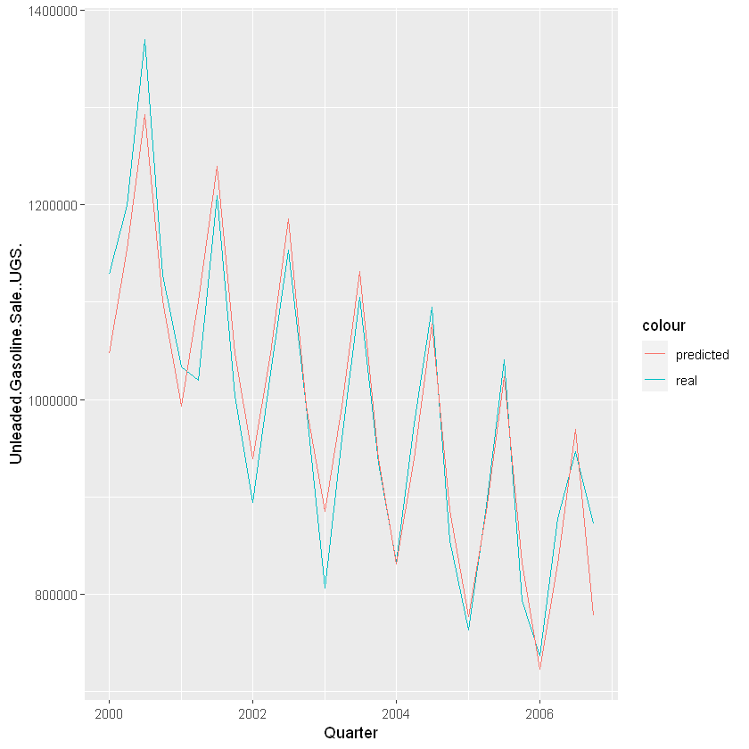

```r
ggplot(PM1 ,aes(x=Quarter)) +
  geom_line(aes(y=Unleaded.Gasoline.Sale..UGS.,color='real')) +
  geom_line(aes(y=predicted_trend,color='predicted'))
```

Quarters are estimated very well but still there are some significant errors

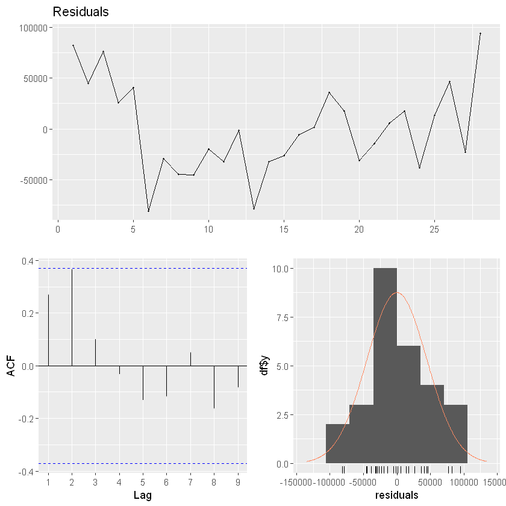

```r
checkresiduals(model1$residuals)
```

Residuals do not have completely stationary mean and variance. residuals are normally distributed. lag 2 has highest value.

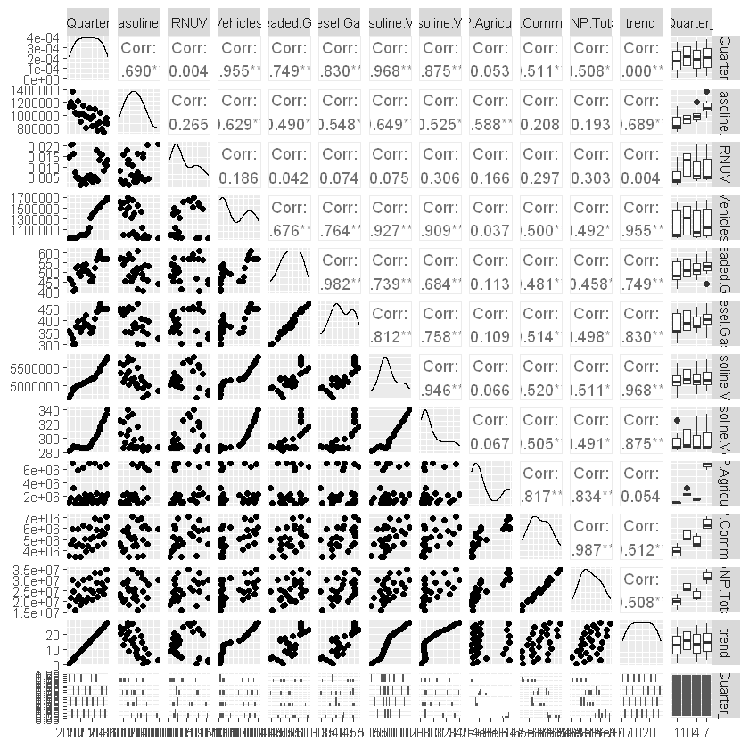

```r
ggpairs(datatr)
```

```r
model2 <- lm(Unleaded.Gasoline.Sale..UGS. ~ trend+ X..LPG.Vehicles..NLPG.+Price.of.Unleaded.Gasoline..PU.+Price.of.Diesel.Gasoline..PG.+X..Unleaded.Gasoline.Vehicles..NUGV.+X..of.Diesel.Gasoline.Vehicles..NDGV.+GNP.Agriculture + Quarter_, datatr)
summary(model2)
```

```
Call:
lm(formula = Unleaded.Gasoline.Sale..UGS. ~ trend + X..LPG.Vehicles..NLPG. +
    Price.of.Unleaded.Gasoline..PU. + Price.of.Diesel.Gasoline..PG. +
    X..Unleaded.Gasoline.Vehicles..NUGV. + X..of.Diesel.Gasoline.Vehicles..NDGV. +
    GNP.Agriculture + Quarter_, data = datatr)

Residuals:
   Min     1Q Median     3Q    Max
-67794 -10461   1987  18461  32208

Coefficients:
                                        Estimate Std. Error t value Pr(>|t|)
(Intercept)                            3.094e+06  8.283e+05   3.735  0.00165
trend                                  1.514e+04  1.284e+04   1.178  0.25486
X..LPG.Vehicles..NLPG.                -2.937e-01  1.804e-01  -1.628  0.12195
Price.of.Unleaded.Gasoline..PU.        2.276e+01  1.017e+03   0.022  0.98241
Price.of.Diesel.Gasoline..PG.         -1.129e+03  1.437e+03  -0.786  0.44295
X..Unleaded.Gasoline.Vehicles..NUGV.  -1.023e+00  3.343e-01  -3.061  0.00708
X..of.Diesel.Gasoline.Vehicles..NDGV.  1.238e+04  3.581e+03   3.456  0.00302
GNP.Agriculture                       -3.613e-02  2.764e-02  -1.307  0.20854
Quarter_10                             1.607e+05  4.385e+04   3.664  0.00192
Quarter_4                              1.463e+05  2.356e+04   6.212 9.48e-06
Quarter_7                              4.953e+05  1.597e+05   3.102  0.00648

(Intercept)                           **
trend
X..LPG.Vehicles..NLPG.
Price.of.Unleaded.Gasoline..PU.
Price.of.Diesel.Gasoline..PG.
X..Unleaded.Gasoline.Vehicles..NUGV.  **
X..of.Diesel.Gasoline.Vehicles..NDGV. **
GNP.Agriculture
Quarter_10                            **
Quarter_4                             ***
Quarter_7                             **
---
Signif. codes:  0 '***' 0.001 '**' 0.01 '*' 0.05 '.' 0.1 ' ' 1

Residual standard error: 29700 on 17 degrees of freedom
Multiple R-squared:  0.9757,	Adjusted R-squared:  0.9613
F-statistic: 68.12 on 10 and 17 DF,  p-value: 1.055e-11
```

```r
PM2=copy(datatr)
PM2[,actual:=Unleaded.Gasoline.Sale..UGS.]
PM2[,predicted_trend:=predict(model2,PM2)]
PM2[,residual_trend:=actual-predicted_trend]
```

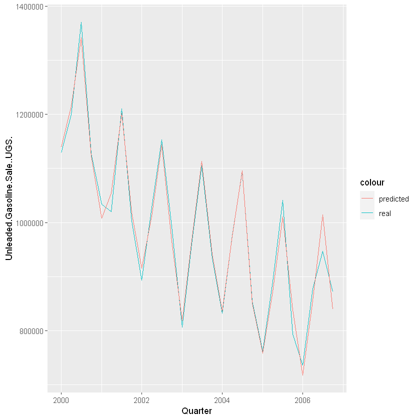

```r
ggplot(PM2 ,aes(x=Quarter)) +
  geom_line(aes(y=Unleaded.Gasoline.Sale..UGS.,color='real')) +
  geom_line(aes(y=predicted_trend,color='predicted'))
```

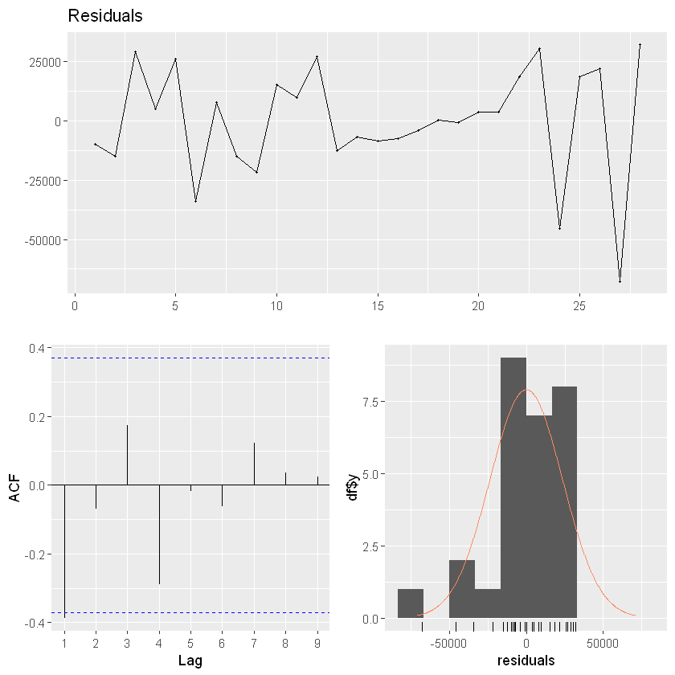

```r
checkresiduals(model2$residuals)
```

```r
datatr$Unleaded.Gasoline.Sale..UGS.lag1=lag(datatr$Unleaded.Gasoline.Sale..UGS.,1)

datatr$X..Unleaded.Gasoline.Vehicles..NUGV.lag5=lag(datatr$X..Unleaded.Gasoline.Vehicles..NUGV.,5)
datatr$X..of.Diesel.Gasoline.Vehicles..NDGV.lag5=lag(datatr$X..of.Diesel.Gasoline.Vehicles..NDGV.,5)
model3 <-lm(Unleaded.Gasoline.Sale..UGS. ~ trend+Price.of.Unleaded.Gasoline..PU.+Price.of.Diesel.Gasoline..PG.+X..Unleaded.Gasoline.Vehicles..NUGV.+X..of.Diesel.Gasoline.Vehicles..NDGV.+GNP.Agriculture +Unleaded.Gasoline.Sale..UGS.lag1+X..Unleaded.Gasoline.Vehicles..NUGV.lag5+X..of.Diesel.Gasoline.Vehicles..NDGV.lag5 + Quarter_, datatr)
summary(model3)
```

```
Call:
lm(formula = Unleaded.Gasoline.Sale..UGS. ~ trend + Price.of.Unleaded.Gasoline..PU. +
    Price.of.Diesel.Gasoline..PG. + X..Unleaded.Gasoline.Vehicles..NUGV. +
    X..of.Diesel.Gasoline.Vehicles..NDGV. + GNP.Agriculture +
    Unleaded.Gasoline.Sale..UGS.lag1 + X..Unleaded.Gasoline.Vehicles..NUGV.lag5 +
    X..of.Diesel.Gasoline.Vehicles..NDGV.lag5 + Quarter_, data = datatr)

Residuals:
   Min     1Q Median     3Q    Max
-40066  -9627    872  10043  30592

Coefficients:
                                            Estimate Std. Error t value
(Intercept)                                3.976e+06  1.964e+06   2.025
trend                                      1.154e+04  2.183e+04   0.528
Price.of.Unleaded.Gasoline..PU.           -5.700e+02  9.344e+02  -0.610
Price.of.Diesel.Gasoline..PG.              3.417e+02  1.217e+03   0.281
X..Unleaded.Gasoline.Vehicles..NUGV.      -1.447e+00  5.427e-01  -2.666
X..of.Diesel.Gasoline.Vehicles..NDGV.      9.099e+03  4.166e+03   2.184
GNP.Agriculture                           -7.666e-03  4.206e-02  -0.182
Unleaded.Gasoline.Sale..UGS.lag1          -4.674e-01  2.370e-01  -1.972
X..Unleaded.Gasoline.Vehicles..NUGV.lag5  -1.654e-01  4.570e-01  -0.362
X..of.Diesel.Gasoline.Vehicles..NDGV.lag5  1.019e+04  9.590e+03   1.062
Quarter_10                                 2.225e+05  4.861e+04   4.578
Quarter_4                                  1.127e+05  4.237e+04   2.660
Quarter_7                                  3.542e+05  2.337e+05   1.515
                                          Pr(>|t|)
(Intercept)                                0.07042 .
trend                                      0.60877
Price.of.Unleaded.Gasoline..PU.            0.55545
Price.of.Diesel.Gasoline..PG.              0.78468
X..Unleaded.Gasoline.Vehicles..NUGV.       0.02363 *
X..of.Diesel.Gasoline.Vehicles..NDGV.      0.05388 .
GNP.Agriculture                            0.85901
Unleaded.Gasoline.Sale..UGS.lag1           0.07690 .
X..Unleaded.Gasoline.Vehicles..NUGV.lag5   0.72490
X..of.Diesel.Gasoline.Vehicles..NDGV.lag5  0.31304
Quarter_10                                 0.00101 **
Quarter_4                                  0.02389 *
Quarter_7                                  0.16064
---
Signif. codes:  0 '***' 0.001 '**' 0.01 '*' 0.05 '.' 0.1 ' ' 1

Residual standard error: 24500 on 10 degrees of freedom
  (5 observations deleted due to missingness)
Multiple R-squared:  0.9826,	Adjusted R-squared:  0.9617
F-statistic: 47.08 on 12 and 10 DF,  p-value: 3.727e-07
```

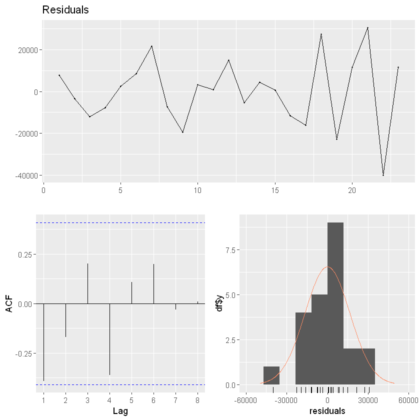

```r
checkresiduals(model3$residuals)
```

```r
PM3=copy(datatr)
PM3[,actual:=Unleaded.Gasoline.Sale..UGS.]
PM3[,predicted_trend:=predict(model3,PM3)]
PM3[,residual_trend:=actual-predicted_trend]
```

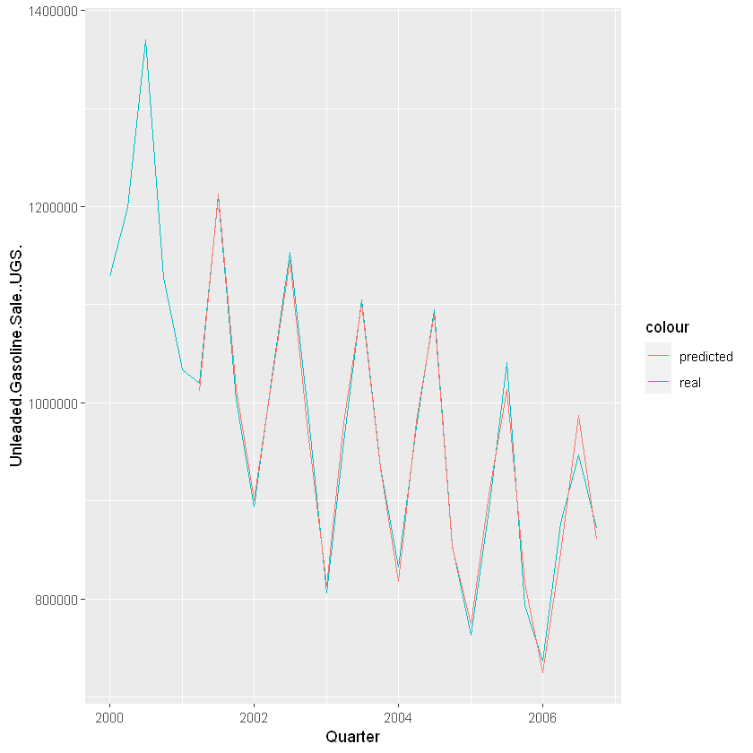

```r
ggplot(PM3 ,aes(x=Quarter)) +
  geom_line(aes(y=Unleaded.Gasoline.Sale..UGS.,color='real')) +
  geom_line(aes(y=predicted_trend,color='predicted'))
```

```r
datafore$Unleaded.Gasoline.Sale..UGS.lag1[1]=datatr$Unleaded.Gasoline.Sale..UGS.[28]

datafore$X..Unleaded.Gasoline.Vehicles..NUGV.lag5[1]=datatr$X..Unleaded.Gasoline.Vehicles..NUGV.[24]
datafore$X..of.Diesel.Gasoline.Vehicles..NDGV.lag5[1]=datatr$X..of.Diesel.Gasoline.Vehicles..NDGV.[24]
datafore[1,"Unleaded.Gasoline.Sale..UGS."]=as.numeric(predict(model3,newdata=datafore[1,]))
datafore$Unleaded.Gasoline.Sale..UGS.lag1[2]=as.numeric(datafore[1,"Unleaded.Gasoline.Sale..UGS."])


datafore[2,"Unleaded.Gasoline.Sale..UGS."]=predict(model3,newdata=datafore[2,])
datafore$Unleaded.Gasoline.Sale..UGS.lag1[3]=as.numeric(datafore[2,"Unleaded.Gasoline.Sale..UGS."])

datafore[3,"Unleaded.Gasoline.Sale..UGS."]=predict(model3,newdata=datafore[3,])
datafore$Unleaded.Gasoline.Sale..UGS.lag1[4]=as.numeric(datafore[3,"Unleaded.Gasoline.Sale..UGS."])

datafore[4,"Unleaded.Gasoline.Sale..UGS."]=predict(model3,newdata=datafore[4,])
datafore[,"Unleaded.Gasoline.Sale..UGS."]
```

| Unleaded.Gasoline.Sale..UGS. |
| --- |
| 703607.2 |
| 856392.2 |
| 949572.2 |
| 767725.5 |

My final model contains Quarterly Seasonality, PU, PG, NUGV, NDGV, GNPA, UGSlag1,NUGVlag5 and NDGVlag5 as regressors. I used some input attributes and build several models of regression in order to be used for forecasting. First of I realized that all data was not stationary by looking at visiual components. I added trend and seasonality in model1 which improved the model significantly. Then I addes the given input as regressors to the model2 which improved the model. Lastly, I added lagged values of the both output attribute and some input attributes. And I decided that model 3 is the best one.